# Visualization in R

gitrific

21 January 2019

# Zródlo danych (opis, informacje o zródle)

Dane do projektu pochodza z Kaggle: https://www.kaggle.com/ramamet4/app-store-apple-data-set-10k-apps/home , sa to statystyki dotyczace sprzedazy aplikacji w App Store. Dane zostaly pobrane z interfejsu iTunes Search API na stronie internetowej Apple Inc. Zostaly takze uzyte narzedzia do web-scrapingu. W zbiorze znajduja sie nastepujace zmienne:

“id” : App ID “track_name”: App Name “size_bytes”: Size (in Bytes) “currency”: Currency Type “price”: Price amount “rating_count_tot”: User Rating counts (for all version) “rating_count_ver”: User Rating counts (for current version) “user_rating” : Average User Rating value (for all version) “user_rating_ver”: Average User Rating value (for current version) “ver” : Latest version code “cont_rating”: Content Rating “prime_genre”: Primary Genre “sup_devices.num”: Number of supporting devices “ipadSc_urls.num”: Number of screenshots showed for display “lang.num”: Number of supported languages “vpp_lic”: Vpp Device Based Licensing Enabled

Wlasnosc danych: Copyright (c) 2018 Ramanathan Perumal, dane udostepnione na mocy licencji GPL 2.0, umozliwiajacej zmiane i udostepnianie wykonanych zmian.

```r
setwd("C:/PiWD")
df <- read.csv("C:/PiWD/AppleStore.csv", header=TRUE, stringsAsFactors=FALSE)
```

# Okreslenie problemu badawczego (stawiane pytania)

Problem badawczy - co wplywa na ocene aplikacji?

# Analiza wstepna danych (eksploracja)

## Wstepna analiza danych - podsumowanie i wglad w dane

Analize danych warto rozpoczac od uzycia kilku prostych funkcji - w celu wyczucia danych.

```r
summary(df)
```

```
##        X               id             track_name
##  Min.   :    1   Min.   :2.817e+08   Length:7197
##  1st Qu.: 2090   1st Qu.:6.001e+08   Class :character
##  Median : 4380   Median :9.781e+08   Mode  :character
##  Mean   : 4759   Mean   :8.631e+08
##  3rd Qu.: 7223   3rd Qu.:1.082e+09
##  Max.   :11097   Max.   :1.188e+09
##    size_bytes          currency             price
##  Min.   :5.898e+05   Length:7197        Min.   :  0.000
##  1st Qu.:4.692e+07   Class :character   1st Qu.:  0.000
##  Median :9.715e+07   Mode  :character   Median :  0.000
##  Mean   :1.991e+08                      Mean   :  1.726
##  3rd Qu.:1.819e+08                      3rd Qu.:  1.990
##  Max.   :4.026e+09                      Max.   :299.990
##  rating_count_tot  rating_count_ver    user_rating    user_rating_ver
##  Min.   :      0   Min.   :     0.0   Min.   :0.000   Min.   :0.000
##  1st Qu.:     28   1st Qu.:     1.0   1st Qu.:3.500   1st Qu.:2.500
##  Median :    300   Median :    23.0   Median :4.000   Median :4.000
##  Mean   :  12893   Mean   :   460.4   Mean   :3.527   Mean   :3.254
##  3rd Qu.:   2793   3rd Qu.:   140.0   3rd Qu.:4.500   3rd Qu.:4.500
##  Max.   :2974676   Max.   :177050.0   Max.   :5.000   Max.   :5.000
##      ver            cont_rating        prime_genre        sup_devices.num
##  Length:7197        Length:7197        Length:7197        Min.   : 9.00
##  Class :character   Class :character   Class :character   1st Qu.:37.00
##  Mode  :character   Mode  :character   Mode  :character   Median :37.00
##                                                           Mean   :37.36
##                                                           3rd Qu.:38.00
##                                                           Max.   :47.00
##  ipadSc_urls.num    lang.num         vpp_lic
##  Min.   :0.000   Min.   : 0.000   Min.   :0.0000
##  1st Qu.:3.000   1st Qu.: 1.000   1st Qu.:1.0000
##  Median :5.000   Median : 1.000   Median :1.0000
##  Mean   :3.707   Mean   : 5.435   Mean   :0.9931
##  3rd Qu.:5.000   3rd Qu.: 8.000   3rd Qu.:1.0000
##  Max.   :5.000   Max.   :75.000   Max.   :1.0000
```

```r
head(df, n = 10)
```

```
##     X        id                                         track_name
## 1   1 281656475                                    PAC-MAN Premium
## 2   2 281796108                          Evernote - stay organized
## 3   3 281940292    WeatherBug - Local Weather, Radar, Maps, Alerts
## 4   4 282614216 eBay: Best App to Buy, Sell, Save! Online Shopping
## 5   5 282935706                                              Bible
## 6   6 283619399                                   Shanghai Mahjong
## 7   7 283646709             PayPal - Send and request money safely
## 8   8 284035177                            Pandora - Music & Radio
## 9   9 284666222                        PCalc - The Best Calculator
## 10 10 284736660                                        Ms. PAC-MAN
##    size_bytes currency price rating_count_tot rating_count_ver user_rating
## 1   100788224      USD  3.99            21292               26         4.0
## 2   158578688      USD  0.00           161065               26         4.0
## 3   100524032      USD  0.00           188583             2822         3.5
```

[output cut: 29 more lines]

```r
tail(df, n= 10)
```

[output not shown]

[output cut: 40 more lines]

Bardzo przydatny w tym celu moze byc tez pakiet dplyr

```r
require(dplyr)
glimpse(df)
```

```
## Observations: 7,197
## Variables: 17
## $ X                <int> 1, 2, 3, 4, 5, 6, 7, 8, 9, 10, 11, 12, 13, 14...
## $ id               <int> 281656475, 281796108, 281940292, 282614216, 2...
## $ track_name       <chr> "PAC-MAN Premium", "Evernote - stay organized...
## $ size_bytes       <dbl> 100788224, 158578688, 100524032, 128512000, 9...
## $ currency         <chr> "USD", "USD", "USD", "USD", "USD", "USD", "US...
## $ price            <dbl> 3.99, 0.00, 0.00, 0.00, 0.00, 0.99, 0.00, 0.0...
## $ rating_count_tot <int> 21292, 161065, 188583, 262241, 985920, 8253, ...
## $ rating_count_ver <int> 26, 26, 2822, 649, 5320, 5516, 879, 3594, 4, ...
## $ user_rating      <dbl> 4.0, 4.0, 3.5, 4.0, 4.5, 4.0, 4.0, 4.0, 4.5, ...
## $ user_rating_ver  <dbl> 4.5, 3.5, 4.5, 4.5, 5.0, 4.0, 4.5, 4.5, 5.0, ...
## $ ver              <chr> "6.3.5", "8.2.2", "5.0.0", "5.10.0", "7.5.1",...
## $ cont_rating      <chr> "4+", "4+", "4+", "12+", "4+", "4+", "4+", "1...
## $ prime_genre      <chr> "Games", "Productivity", "Weather", "Shopping...
## $ sup_devices.num  <int> 38, 37, 37, 37, 37, 47, 37, 37, 37, 38, 38, 3...
## $ ipadSc_urls.num  <int> 5, 5, 5, 5, 5, 5, 0, 4, 5, 0, 4, 0, 4, 0, 5, ...
## $ lang.num         <int> 10, 23, 3, 9, 45, 1, 19, 1, 1, 10, 11, 6, 33,...
## $ vpp_lic          <int> 1, 1, 1, 1, 1, 1, 1, 1, 1, 1, 1, 1, 1, 1, 1, ...
```

Usune zbedna dana i dodam kolumne z glównym numerem release’u - moze doswiadczenie w tworzeniu aplikacji ma wplyw na ich popularnosc? Moze im dluzej developowana aplikacja, tym lepsza jej percepcja?

```r
df <- df[,-1]
df$main_release <- sub("\\..*", "", df$ver)
df$main_release <- sub(".* ", "", df$main_release)
df$main_release <-  as.numeric(df$main_release)
sum(is.na(df$main_release))
```

```
## [1] 6
```

Zakladam, ze brak wartosci w 6 przypadkach nie ma az takiego znaczenia. #Wizualizacja posiadanych danych

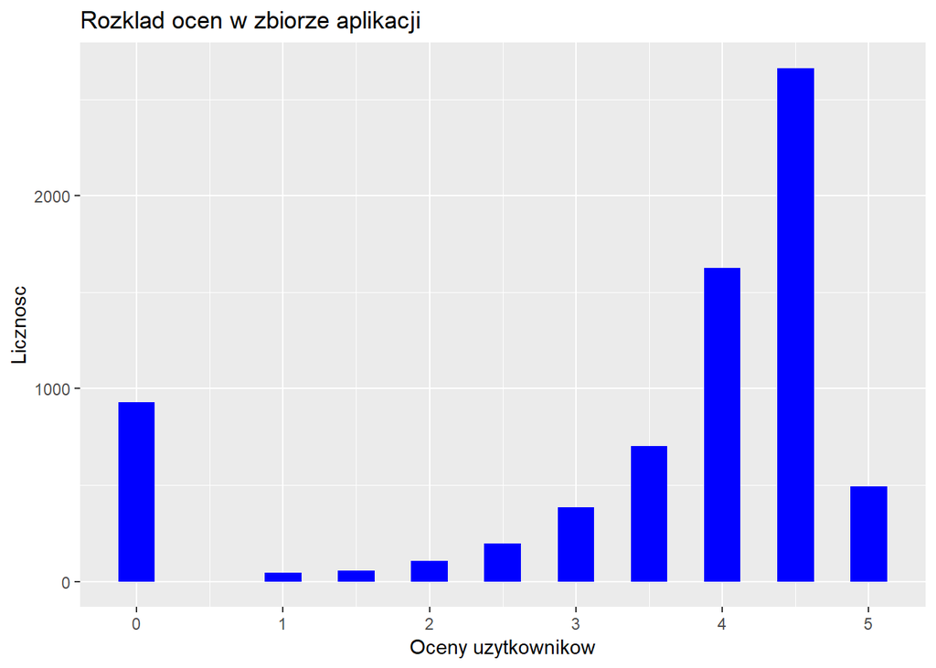

```r
require(ggplot2)
p <- ggplot(df) + geom_histogram(aes(x=user_rating), fill="blue",binwidth = 0.25) + xlab("Oceny uzytkownikow") +ylab("Licznosc")
p +  ggtitle("Rozklad ocen w zbiorze aplikacji")
```